# robseq_example

2023-11-17

# Importing libraries

```r
library(Robseq)
library(edgeR)
library(doParallel)
library(EnhancedVolcano)
```

# Loading Example Data

```r
load("Alzheimer_counts.RData")
```

```r
load("Alzheimer_metadata.RData")
```

# Snapshot of data

A typical bulk RNA-seq gene expression count data frame looks something like below. Note, the genes should be in the rows and the samples in columns

```r
features[1:5, 1:5]
```

```
##          GSM2516806 GSM2516807 GSM2516808 GSM2516809 GSM2516810
## TSPAN6          652        520        170        380        226
## TNMD              3          3          0          4          4
## DPM1            413        797        131        566        336
## SCYL3           460        423         80        309        116
## C1orf112        203        148         44        143         51
```

A typical metadata data frame looks something like below. Note, in our pipeline the user must include a column labeled as “Exposure” which should be the variable which will be used by Robseq in performing differential expression analysis. If the user has a different label for the treatment/condition or disease status variable then the user should supply that name via “expVar” argument in Robseq

```r
metadata[1:5, 1:5]
```

```
##       Sample Age            Exposure braak.score rin_score
## 1 GSM2516806  97 Alzheimer's disease           V       6.9
## 2 GSM2516807  97 Alzheimer's disease          IV       7.1
## 3 GSM2516808  87 Alzheimer's disease           V       6.1
## 4 GSM2516809  82             control         III       6.8
## 5 GSM2516810  80 Alzheimer's disease           V       5.5
```

# Preprocessing

A typical preprocessing step is to filter lowly abundant genes. We do so using edgeR’s “filterByExpr” function

```r
keep.exprs <- filterByExpr(features, group = as.factor(metadata$Exposure))
paste(length(which(!keep.exprs)), ' lowly expressed genes were filtered out', sep = '')
```

```
## [1] "7254 lowly expressed genes were filtered out"
```

```r
features <- features[keep.exprs, ]
```

# Performing differential expression analysis using Robseq

```r
fit <- Robseq::robust.dge(features = features,
                          metadata = metadata,
                          norm.method = "TMM",
                          expVar =  "Exposure",
                          coVars = NULL,
                          parallel = TRUE,
                          ncores = detectCores() - 2,
                          verbose = FALSE)
```

# Obtaining results from Robseq

After performing DGE analysis you can extract the results table in the following manner

```r
results <- fit$res
```

The results table from Robseq should look something like the following

```r
results[1:5,]
```

```
##        Genes log2FC    SE       L.CI       U.CI         Pval      adjPval
## 223    BAZ1B -0.332 0.041 -0.2516415 -0.4123585 2.817072e-11 3.011794e-07
## 3552 SLC6A12 -1.098 0.139 -0.8255650 -1.3704350 9.860113e-11 3.011794e-07
## 3559   PRMT8  1.218 0.155  1.5217944  0.9142056 9.711422e-11 3.011794e-07
## 5097    NRN1  0.966 0.122  1.2051156  0.7268844 7.282548e-11 3.011794e-07
## 8650   PART1  1.145 0.147  1.4331147  0.8568853 1.171839e-10 3.011794e-07
```

# Volcano plot to visualize DGE results

Volcano plot to visualize the DGE results obtained from Robseq

```r
  EnhancedVolcano(results,
    lab = results$Genes,
    x = 'log2FC',
    y = 'adjPval')
```

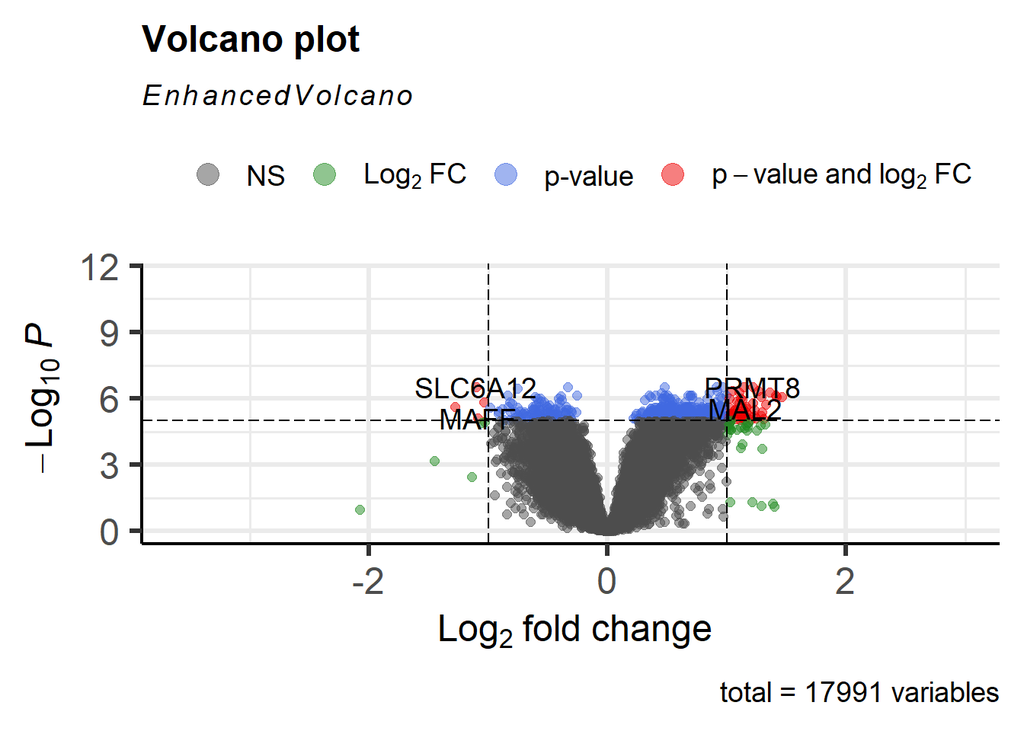